# vgt_STGT Study 1

Mariya Cherkasova

Jan 1, 2020

VGT analysis for sign- and goal trackers from Study 1 (Cherkasova et al 2018, JN)

# Compute gaze index; identify ST and GT

Interest period for fixations excludes the orienting response, which we are assuming is the first 1000ms of the CS phase

Files excluded from analysis for insufficient trials: 121,154,171,177, 209 (mislabeled as 709)

Participants who spend >80 of the time looking at neither the CS nor the US are also excluded

Missing ST data file for 219; manual IA correction for drift: 141,155,228, 158

Gaze index computed as %dwell_time(CS)-%dwell_time(US)

STs and GTs identified using tertiary split

# Gaze index histograms

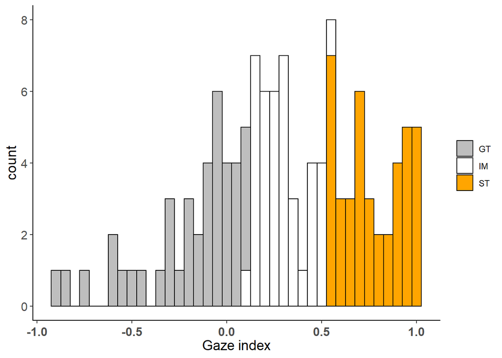

# CR expression as a function of hemiblock

```
##
## Call:
## glm(formula = gazeidx ~ half * STGT_ter + version + cs, data = h1_2_tr_ter)
##
## Deviance Residuals:
##      Min        1Q    Median        3Q       Max
## -1.01825  -0.16577   0.01755   0.19619   0.86009
##
## Coefficients:
##                              Estimate Std. Error t value Pr(>|t|)
## (Intercept)                -7.448e-02  4.860e-02  -1.532   0.1264
## halfhemiblock 2            -1.518e-01  4.823e-02  -3.148   0.0018 **
## STGT_terST                  6.787e-01  4.831e-02  14.047  < 2e-16 ***
## versionPIT2                 6.771e-02  4.718e-02   1.435   0.1522
## versionPIT3                 2.528e-02  4.840e-02   0.522   0.6019
## versionPIT4                 3.143e-02  4.840e-02   0.649   0.5166
## csplus                     -1.241e-17  3.410e-02   0.000   1.0000
## halfhemiblock 2:STGT_terST  2.821e-01  6.820e-02   4.137 4.53e-05 ***
## ---
## Signif. codes:  0 '***' 0.001 '**' 0.01 '*' 0.05 '.' 0.1 ' ' 1
##
## (Dispersion parameter for gaussian family taken to be 0.0930284)
##
##     Null deviance: 84.174  on 319  degrees of freedom
## Residual deviance: 29.025  on 312  degrees of freedom
## AIC: 158.07
##
## Number of Fisher Scoring iterations: 2
```

```
##                              est 2.5 % 97.5 %
## (Intercept)                0.928 0.844  1.021
## halfhemiblock 2            0.859 0.782  0.944
## STGT_terST                 1.971 1.793  2.167
## versionPIT2                1.070 0.976  1.174
## versionPIT3                1.026 0.933  1.128
## versionPIT4                1.032 0.939  1.135
## csplus                     1.000 0.935  1.069
## halfhemiblock 2:STGT_terST 1.326 1.160  1.516
```

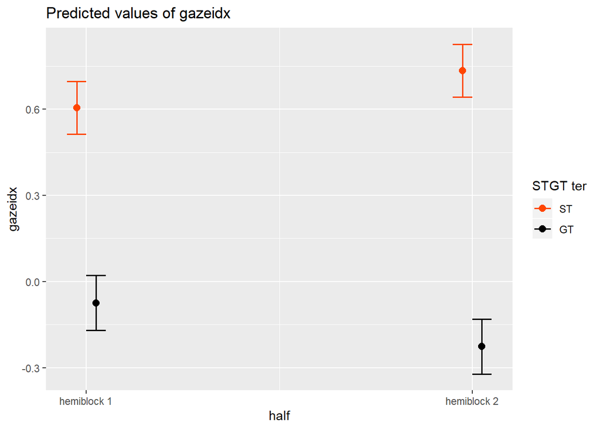

```
##
## Call:
## glm(formula = gazeidx ~ half + cs + version, data = h1_2_tr_ter_st)
##
## Deviance Residuals:
##      Min        1Q    Median        3Q       Max
## -0.96390  -0.12069  -0.00527   0.18671   0.38243
##
## Coefficients:
##                   Estimate Std. Error t value Pr(>|t|)
## (Intercept)      5.964e-01  4.296e-02  13.884  < 2e-16 ***
## halfhemiblock 2  1.303e-01  3.720e-02   3.503 0.000602 ***
## csplus          -8.325e-17  3.720e-02   0.000 1.000000
## versionPIT2      2.119e-02  5.037e-02   0.421 0.674554
## versionPIT3      8.647e-02  5.187e-02   1.667 0.097554 .
## versionPIT4      5.673e-02  5.187e-02   1.094 0.275856
## ---
## Signif. codes:  0 '***' 0.001 '**' 0.01 '*' 0.05 '.' 0.1 ' ' 1
##
## (Dispersion parameter for gaussian family taken to be 0.05535396)
##
##     Null deviance: 9.3816  on 159  degrees of freedom
## Residual deviance: 8.5245  on 154  degrees of freedom
## AIC: -1.0962
##
## Number of Fisher Scoring iterations: 2
```

```
##                  est 2.5 % 97.5 %
## (Intercept)     1.82 1.669   1.97
## halfhemiblock 2 1.14 1.059   1.23
## csplus          1.00 0.930   1.08
## versionPIT2     1.02 0.925   1.13
## versionPIT3     1.09 0.985   1.21
## versionPIT4     1.06 0.956   1.17
```

```
##
## Call:
## glm(formula = gazeidx ~ half + cs + version, data = h1_2_tr_ter_gt)
##
## Deviance Residuals:
##      Min        1Q    Median        3Q       Max
## -0.83163  -0.23968   0.03262   0.20366   0.86859
##
## Coefficients:
##                   Estimate Std. Error t value Pr(>|t|)
## (Intercept)     -6.404e-02  7.242e-02  -0.884  0.37795
## halfhemiblock 2 -1.518e-01  5.705e-02  -2.661  0.00862 **
## csplus          -1.389e-16  5.705e-02   0.000  1.00000
## versionPIT2      1.067e-01  8.109e-02   1.315  0.19030
## versionPIT3     -3.319e-02  8.290e-02  -0.400  0.68945
## versionPIT4      5.273e-03  8.290e-02   0.064  0.94936
## ---
## Signif. codes:  0 '***' 0.001 '**' 0.01 '*' 0.05 '.' 0.1 ' ' 1
##
## (Dispersion parameter for gaussian family taken to be 0.1302096)
##
##     Null deviance: 21.440  on 159  degrees of freedom
## Residual deviance: 20.052  on 154  degrees of freedom
## AIC: 135.77
##
## Number of Fisher Scoring iterations: 2
```

```
##                   est 2.5 % 97.5 %
## (Intercept)     0.938 0.814  1.081
## halfhemiblock 2 0.859 0.768  0.961
## csplus          1.000 0.894  1.118
## versionPIT2     1.113 0.949  1.304
## versionPIT3     0.967 0.822  1.138
## versionPIT4     1.005 0.855  1.183
```

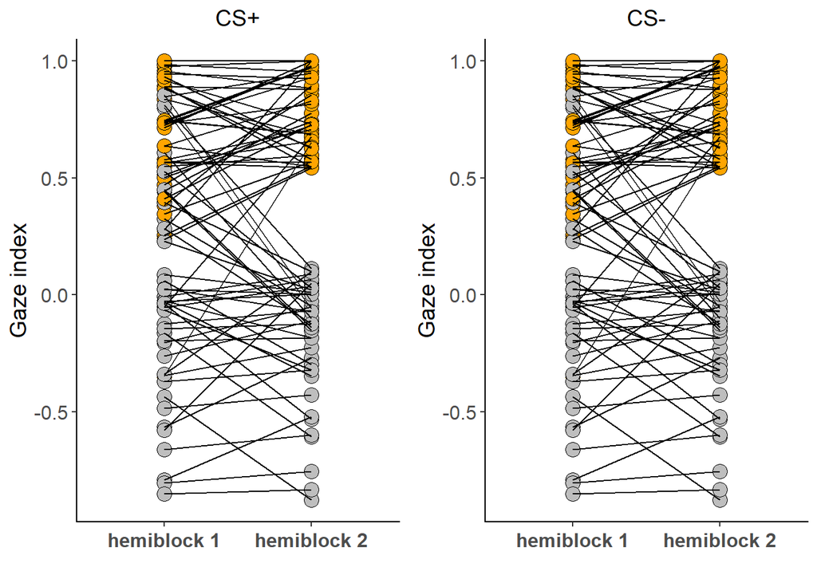

# Data preprocessing Study 1

# Isometric log ratio transformations.

We are assuming here that both probabilities and magnitudes are compositional data. This is clearly the case with proabilities,as they always add up to 1.It also apprears to be the case with magnitudes: data are defined as compositional when its components cary only relative information, which is the case with the magnitudes. That is each gamble inherently carries a maximum gain value, and one gain value is always evaluated relative to the other.

# Comine with Pavlovian data

# GLM1: Cues * STGT *EVR interaction Gaze index calculated based on the interest period excluding the first 1000ms considered the Orienting response Quantified as % of total fixation time spent of CS and US ST and GT defined using a teriary split

```
## Generalized linear mixed model fit by maximum likelihood (Laplace
##   Approximation) [glmerMod]
##  Family: binomial  ( logit )
## Formula: riskychoice ~ STGT * cues_factor * EVR + order + Rep_centered +
##     (EVR + Rep_centered | subj)
##    Data: data_Xim
## Control: glmerControl(optimizer = "bobyqa")
##
##      AIC      BIC   logLik deviance df.resid
##   6158.3   6270.1  -3063.1   6126.3     7984
##
## Scaled residuals:
##     Min      1Q  Median      3Q     Max
## -6.7484 -0.3963 -0.1491  0.3357  7.6055
##
## Random effects:
##  Groups Name         Variance Std.Dev. Corr
##  subj   (Intercept)  0.95022  0.9748
##         EVR          3.81642  1.9536   -0.01
##         Rep_centered 0.01317  0.1148   -0.44  0.06
## Number of obs: 8000, groups:  subj, 80
##
## Fixed effects:
##                              Estimate Std. Error z value Pr(>|z|)
## (Intercept)                  -0.88022    0.23704  -3.713 0.000205 ***
## STGTST                        0.31619    0.28793   1.098 0.272147
## cues_factoruncued            -0.70983    0.31775  -2.234 0.025488 *
## EVR                           3.52884    0.45161   7.814 5.55e-15 ***
## orderVI                      -0.37977    0.22420  -1.694 0.090284 .
## Rep_centered                  0.07022    0.01778   3.950 7.83e-05 ***
## STGTST:cues_factoruncued      0.51486    0.45533   1.131 0.258164
## STGTST:EVR                    0.12003    0.61566   0.195 0.845425
## cues_factoruncued:EVR        -0.15137    0.67042  -0.226 0.821372
## STGTST:cues_factoruncued:EVR  1.31462    0.96823   1.358 0.174540
## ---
## Signif. codes:  0 '***' 0.001 '**' 0.01 '*' 0.05 '.' 0.1 ' ' 1
##
## Correlation of Fixed Effects:
##             (Intr) STGTST cs_fct EVR    ordrVI Rp_cnt STGTST:c_ STGTST:E
## STGTST      -0.633
## cus_fctrncd -0.581  0.494
## EVR         -0.037  0.028  0.024
## orderVI     -0.425 -0.049 -0.028 -0.014
## Rep_centerd -0.151 -0.005 -0.003  0.025 -0.006
## STGTST:cs_f  0.438 -0.634 -0.701 -0.014 -0.051  0.011
## STGTST:EVR   0.022 -0.026 -0.018 -0.726  0.004  0.016  0.016
## cs_fctr:EVR  0.018 -0.018 -0.052 -0.669  0.010  0.011  0.035     0.494
## STGTST:_:EV -0.012  0.017  0.036  0.464 -0.008 -0.013 -0.043    -0.641
##             c_:EVR
## STGTST
## cus_fctrncd
## EVR
## orderVI
## Rep_centerd
## STGTST:cs_f
## STGTST:EVR
## cs_fctr:EVR
## STGTST:_:EV -0.696
```

```
##                                 est  2.5 % 97.5 %
## (Intercept)                   0.415  0.261  0.660
## STGTST                        1.372  0.780  2.412
## cues_factoruncued             0.492  0.264  0.917
## EVR                          34.084 14.065 82.598
## orderVI                       0.684  0.441  1.061
## Rep_centered                  1.073  1.036  1.111
## STGTST:cues_factoruncued      1.673  0.686  4.085
## STGTST:EVR                    1.128  0.337  3.769
## cues_factoruncued:EVR         0.860  0.231  3.198
## STGTST:cues_factoruncued:EVR  3.723  0.558 24.837
```

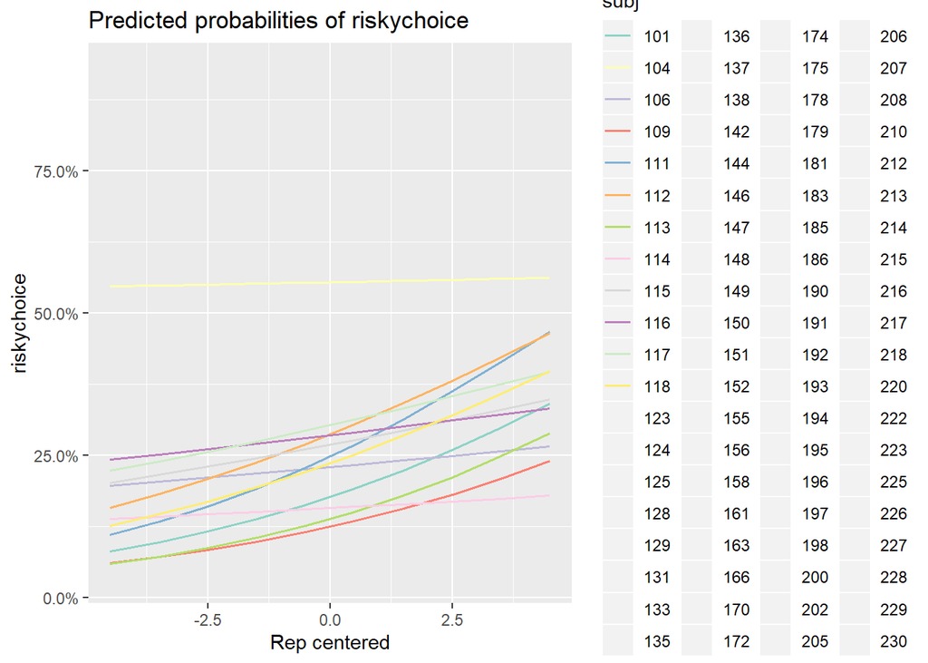

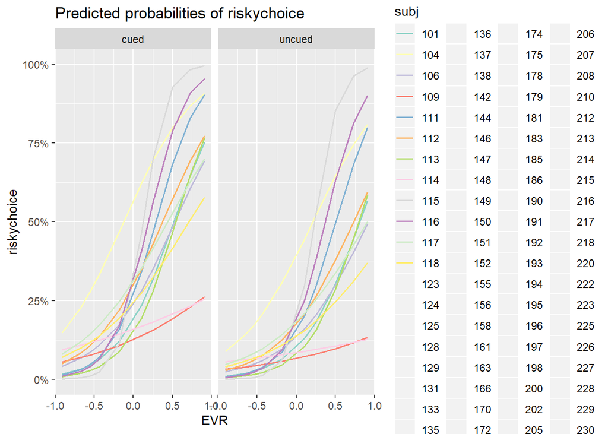

# GLM1 excluding #214

Excluding 214, which is a highly influential observation, resulted in a trend for a main effect of ST. However, there is no clear reason to exclude this observation.

```
## Generalized linear mixed model fit by maximum likelihood (Laplace
##   Approximation) [glmerMod]
##  Family: binomial  ( logit )
## Formula: riskychoice ~ STGT * cues_factor * EVR + order + Rep_centered +
##     (EVR + Rep_centered | subj)
##    Data: dataX214
## Control: glmerControl(optimizer = "bobyqa")
##
##      AIC      BIC   logLik deviance df.resid
##   6085.0   6196.6  -3026.5   6053.0     7884
##
## Scaled residuals:
##     Min      1Q  Median      3Q     Max
## -6.7831 -0.4008 -0.1535  0.3264  7.5192
##
## Random effects:
##  Groups Name         Variance Std.Dev. Corr
##  subj   (Intercept)  0.75096  0.8666
##         EVR          3.74200  1.9344    0.10
##         Rep_centered 0.01306  0.1143   -0.39  0.03
## Number of obs: 7900, groups:  subj, 79
##
## Fixed effects:
##                              Estimate Std. Error z value Pr(>|z|)
## (Intercept)                  -1.09431    0.22259  -4.916 8.82e-07 ***
## STGTST                        0.48493    0.26620   1.822   0.0685 .
## cues_factoruncued            -0.52476    0.29365  -1.787   0.0739 .
## EVR                           3.65390    0.46061   7.933 2.14e-15 ***
## orderVI                      -0.26385    0.20638  -1.278   0.2011
## Rep_centered                  0.07153    0.01787   4.004 6.24e-05 ***
## STGTST:cues_factoruncued      0.31095    0.41841   0.743   0.4574
## STGTST:EVR                   -0.03422    0.62077  -0.055   0.9560
## cues_factoruncued:EVR        -0.31591    0.67432  -0.468   0.6394
## STGTST:cues_factoruncued:EVR  1.47543    0.96743   1.525   0.1272
## ---
## Signif. codes:  0 '***' 0.001 '**' 0.01 '*' 0.05 '.' 0.1 ' ' 1
##
## Correlation of Fixed Effects:
##             (Intr) STGTST cs_fct EVR    ordrVI Rp_cnt STGTST:c_ STGTST:E
## STGTST      -0.649
## cus_fctrncd -0.595  0.508
## EVR          0.030 -0.028 -0.028
## orderVI     -0.437 -0.029 -0.009 -0.012
## Rep_centerd -0.129 -0.006 -0.006  0.010 -0.007
## STGTST:cs_f  0.453 -0.641 -0.707  0.022 -0.065  0.012
## STGTST:EVR  -0.027  0.054  0.020 -0.736  0.003  0.020 -0.035
## cs_fctr:EVR -0.027  0.021  0.028 -0.680  0.007  0.015 -0.022     0.510
## STGTST:_:EV  0.019 -0.035 -0.019  0.476 -0.006 -0.015  0.038    -0.648
##             c_:EVR
## STGTST
## cus_fctrncd
## EVR
## orderVI
## Rep_centerd
## STGTST:cs_f
## STGTST:EVR
## cs_fctr:EVR
## STGTST:_:EV -0.702
```

```
##                                 est  2.5 % 97.5 %
## (Intercept)                   0.335  0.216  0.518
## STGTST                        1.624  0.964  2.736
## cues_factoruncued             0.592  0.333  1.052
## EVR                          38.625 15.660 95.267
## orderVI                       0.768  0.513  1.151
## Rep_centered                  1.074  1.037  1.112
## STGTST:cues_factoruncued      1.365  0.601  3.099
## STGTST:EVR                    0.966  0.286  3.262
## cues_factoruncued:EVR         0.729  0.194  2.734
## STGTST:cues_factoruncued:EVR  4.373  0.657 29.124
```

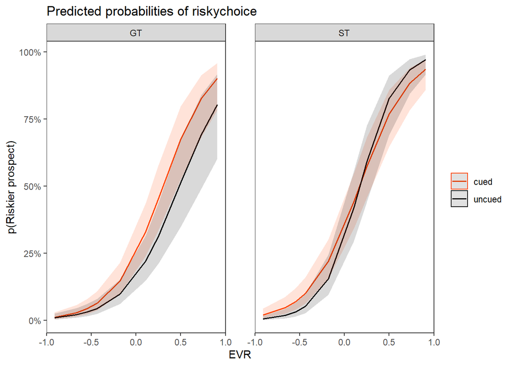

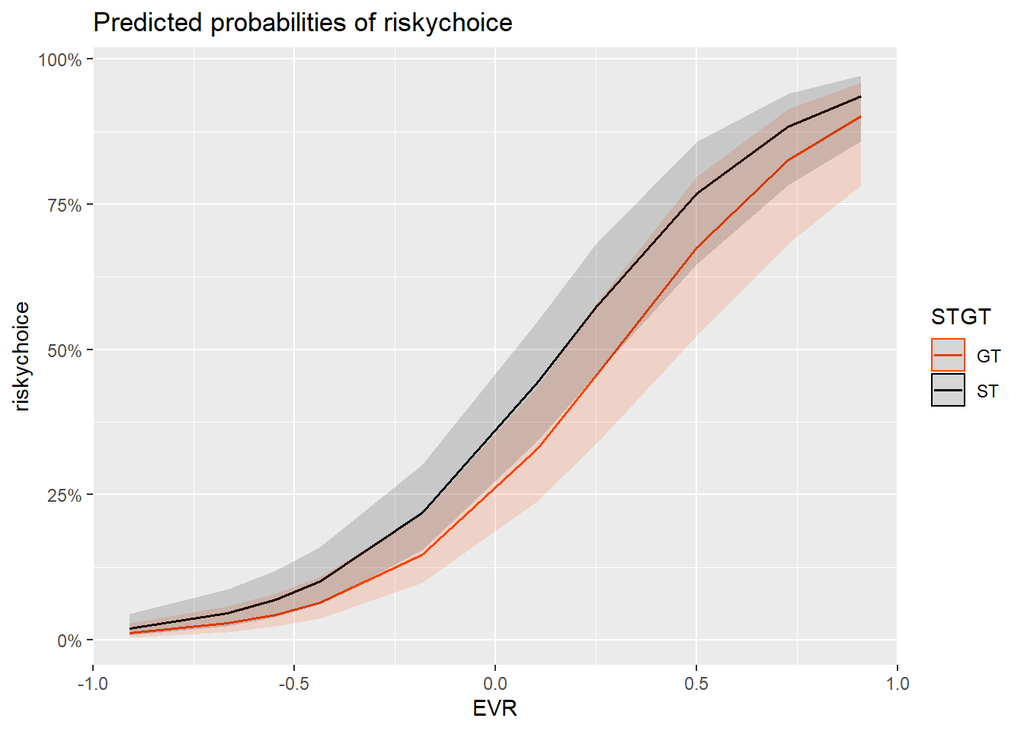

# GLM dimensional: Cues*Gaze_index*EVR

```
## Generalized linear mixed model fit by maximum likelihood (Laplace
##   Approximation) [glmerMod]
##  Family: binomial  ( logit )
## Formula:
## riskychoice ~ Gaze_index * cues_factor * EVR + order + Rep_centered +
##     (EVR + Rep_centered | subj)
##    Data: data
## Control: glmerControl(optimizer = "bobyqa")
##
##      AIC      BIC   logLik deviance df.resid
##   9393.0   9511.3  -4680.5   9361.0    11984
##
## Scaled residuals:
##     Min      1Q  Median      3Q     Max
## -7.2683 -0.4132 -0.1636  0.3340  7.2808
##
## Random effects:
##  Groups Name         Variance Std.Dev. Corr
##  subj   (Intercept)  0.89940  0.9484
##         EVR          4.02350  2.0059    0.13
##         Rep_centered 0.01575  0.1255   -0.46 -0.16
## Number of obs: 12000, groups:  subj, 120
##
## Fixed effects:
##                                  Estimate Std. Error z value Pr(>|z|)
## (Intercept)                      -0.64579    0.16576  -3.896 9.78e-05 ***
## Gaze_index                        0.06282    0.26046   0.241 0.809413
## cues_factoruncued                -0.75677    0.21188  -3.572 0.000355 ***
## EVR                               3.74157    0.33012  11.334  < 2e-16 ***
## orderVI                          -0.39089    0.17617  -2.219 0.026498 *
## Rep_centered                      0.06769    0.01519   4.457 8.30e-06 ***
## Gaze_index:cues_factoruncued      0.90156    0.41268   2.185 0.028914 *
## Gaze_index:EVR                   -0.31351    0.58678  -0.534 0.593142
## cues_factoruncued:EVR            -0.38071    0.47316  -0.805 0.421054
## Gaze_index:cues_factoruncued:EVR  1.45474    0.92411   1.574 0.115442
## ---
## Signif. codes:  0 '***' 0.001 '**' 0.01 '*' 0.05 '.' 0.1 ' ' 1
##
## Correlation of Fixed Effects:
##             (Intr) Gz_ndx cs_fct EVR    ordrVI Rp_cnt Gz_n:_ G_:EVR c_:EVR
## Gaze_index  -0.438
## cus_fctrncd -0.571  0.392
## EVR          0.044 -0.016 -0.028
## orderVI     -0.447 -0.115 -0.051 -0.016
## Rep_centerd -0.186 -0.007 -0.004 -0.069 -0.004
## Gz_ndx:cs_f  0.309 -0.622 -0.567  0.015 -0.004  0.007
## Gaz_ndx:EVR -0.017  0.042  0.013 -0.561  0.005  0.013 -0.028
## cs_fctr:EVR -0.026  0.013  0.018 -0.687  0.008  0.012 -0.003  0.394
## Gz_nd:_:EVR  0.013 -0.027 -0.002  0.354 -0.007 -0.007  0.017 -0.635 -0.559
```

[output not shown]

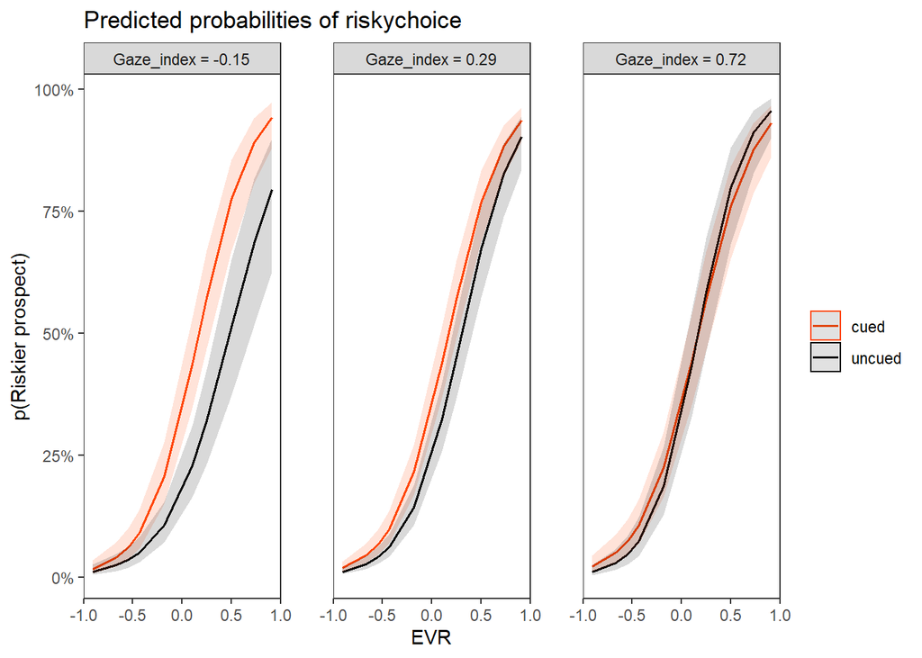

# GLM dimensional: Cues*Gaze_index*EVR; excluding 214

```
## Generalized linear mixed model fit by maximum likelihood (Laplace
##   Approximation) [glmerMod]
##  Family: binomial  ( logit )
## Formula:
## riskychoice ~ Gaze_index * cues_factor * EVR + order + Rep_centered +
##     (EVR + Rep_centered | subj)
##    Data: data_x214
## Control: glmerControl(optimizer = "bobyqa")
##
##      AIC      BIC   logLik deviance df.resid
##   9317.7   9435.8  -4642.8   9285.7    11884
##
## Scaled residuals:
##     Min      1Q  Median      3Q     Max
## -7.2768 -0.4146 -0.1687  0.3287  7.2037
##
## Random effects:
##  Groups Name         Variance Std.Dev. Corr
##  subj   (Intercept)  0.76753  0.8761
##         EVR          3.92312  1.9807    0.21
##         Rep_centered 0.01572  0.1254   -0.43 -0.20
## Number of obs: 11900, groups:  subj, 119
##
## Fixed effects:
##                                  Estimate Std. Error z value Pr(>|z|)
## (Intercept)                      -0.81565    0.16171  -5.044 4.56e-07 ***
## Gaze_index                        0.35453    0.25696   1.380  0.16768
## cues_factoruncued                -0.59523    0.20356  -2.924  0.00346 **
## EVR                               3.90209    0.34133  11.432  < 2e-16 ***
## orderVI                          -0.33448    0.16534  -2.023  0.04307 *
## Rep_centered                      0.06821    0.01525   4.473 7.72e-06 ***
## Gaze_index:cues_factoruncued      0.58837    0.39627   1.485  0.13761
## Gaze_index:EVR                   -0.68393    0.61087  -1.120  0.26289
## cues_factoruncued:EVR            -0.57691    0.47777  -1.208  0.22724
## Gaze_index:cues_factoruncued:EVR  1.83808    0.93170   1.973  0.04852 *
## ---
## Signif. codes:  0 '***' 0.001 '**' 0.01 '*' 0.05 '.' 0.1 ' ' 1
##
## Correlation of Fixed Effects:
##             (Intr) Gz_ndx cs_fct EVR    ordrVI Rp_cnt Gz_n:_ G_:EVR c_:EVR
## Gaze_index  -0.489
## cus_fctrncd -0.596  0.428
## EVR          0.094 -0.047 -0.069
## orderVI     -0.444 -0.090 -0.037 -0.014
## Rep_centerd -0.165 -0.010 -0.006 -0.085 -0.004
## Gz_ndx:cs_f  0.349 -0.642 -0.585  0.035 -0.016  0.009
## Gaz_ndx:EVR -0.044  0.101  0.035 -0.603  0.003  0.018 -0.067
## cs_fctr:EVR -0.062  0.036  0.083 -0.704  0.006  0.016 -0.040  0.435
## Gz_nd:_:EVR  0.031 -0.066 -0.038  0.394 -0.006 -0.011  0.084 -0.657 -0.580
```

[output not shown]

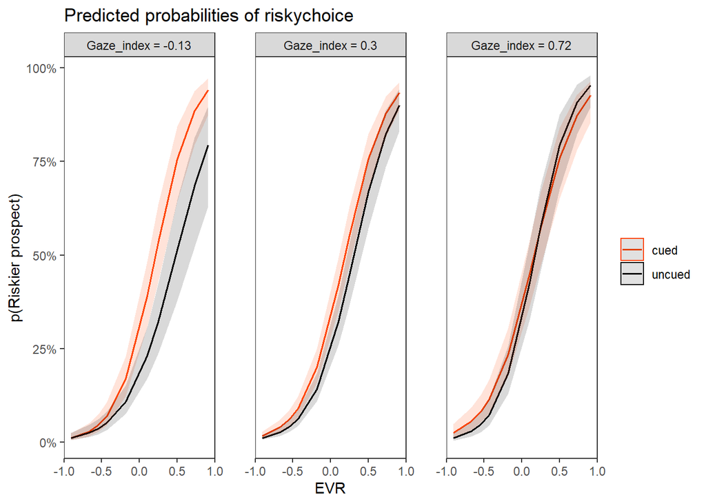

Outliers

# GLM1: Model diagnostics

Residuals

Influence

dfbetas

Cooks

Model significance

# GLM2: Model diagnostics

Residuals

Influence

dfbetas

Cooks

Model significance

## Previous feedback effects

```
## Generalized linear mixed model fit by maximum likelihood (Laplace
##   Approximation) [glmerMod]
##  Family: binomial  ( logit )
## Formula: riskychoice ~ cues_factor * continualw * Gaze_index + order +
##     Rep_centered + (Rep_centered | subj)
##    Data: data
## Control: glmerControl(optimizer = "bobyqa")
##
##      AIC      BIC   logLik deviance df.resid
##  14082.0  14178.1  -7028.0  14056.0    11987
##
## Scaled residuals:
##     Min      1Q  Median      3Q     Max
## -3.6024 -0.7341 -0.4567  0.9485 17.4950
##
## Random effects:
##  Groups Name         Variance Std.Dev. Corr
##  subj   (Intercept)  0.343910 0.5864
##         Rep_centered 0.003204 0.0566   -0.85
## Number of obs: 12000, groups:  subj, 120
##
## Fixed effects:
##                                          Estimate Std. Error z value
## (Intercept)                              0.025593   0.101764   0.251
## cues_factoruncued                       -0.548829   0.129266  -4.246
## continualw                              -0.379284   0.026432 -14.349
## Gaze_index                              -0.026231   0.158759  -0.165
## orderVI                                 -0.203679   0.102378  -1.989
## Rep_centered                             0.042048   0.008965   4.690
## cues_factoruncued:continualw             0.023689   0.039234   0.604
## cues_factoruncued:Gaze_index             0.605095   0.248973   2.430
## continualw:Gaze_index                   -0.036630   0.047153  -0.777
## cues_factoruncued:continualw:Gaze_index  0.116828   0.073608   1.587
##                                         Pr(>|z|)
## (Intercept)                               0.8014
## cues_factoruncued                       2.18e-05 ***
## continualw                               < 2e-16 ***
## Gaze_index                                0.8688
## orderVI                                   0.0466 *
## Rep_centered                            2.73e-06 ***
## cues_factoruncued:continualw              0.5460
## cues_factoruncued:Gaze_index              0.0151 *
## continualw:Gaze_index                     0.4373
## cues_factoruncued:continualw:Gaze_index   0.1125
## ---
## Signif. codes:  0 '***' 0.001 '**' 0.01 '*' 0.05 '.' 0.1 ' ' 1
##
## Correlation of Fixed Effects:
##             (Intr) cs_fct cntnlw Gz_ndx ordrVI Rp_cnt cs_fc: cs_:G_ cnt:G_
## cus_fctrncd -0.567
## continualw  -0.259  0.205
## Gaze_index  -0.434  0.388  0.169
## orderVI     -0.426 -0.054  0.001 -0.109
## Rep_centerd -0.267  0.001 -0.009 -0.013  0.004
## cs_fctrncd:  0.172 -0.297 -0.674 -0.114  0.000  0.012
## cs_fctrn:G_  0.312 -0.567 -0.108 -0.627 -0.010 -0.007  0.172
## cntnlw:Gz_n  0.146 -0.115 -0.559 -0.300  0.001  0.001  0.376  0.192
## cs_fctr::G_ -0.092  0.176  0.358  0.192 -0.001 -0.004 -0.608 -0.292 -0.641
```

```
## Generalized linear mixed model fit by maximum likelihood (Laplace
##   Approximation) [glmerMod]
##  Family: binomial  ( logit )
## Formula:
## riskychoice ~ cues_factor * continualw * STGT + order + Rep_centered +
##     (Rep_centered | subj)
##    Data: data_Xim
## Control: glmerControl(optimizer = "bobyqa")
##
##      AIC      BIC   logLik deviance df.resid
##   9373.7   9464.5  -4673.9   9347.7     7987
##
## Scaled residuals:
##     Min      1Q  Median      3Q     Max
## -3.4483 -0.7368 -0.4476  0.9427 18.2236
##
## Random effects:
##  Groups Name         Variance Std.Dev. Corr
##  subj   (Intercept)  0.362141 0.60178
##         Rep_centered 0.001341 0.03662  -0.97
## Number of obs: 8000, groups:  subj, 80
##
## Fixed effects:
##                                      Estimate Std. Error z value Pr(>|z|)
## (Intercept)                         -0.085852   0.148958  -0.576 0.564376
## cues_factoruncued                   -0.524849   0.199324  -2.633 0.008460
## continualw                          -0.378682   0.038652  -9.797  < 2e-16
## STGTST                               0.194814   0.180826   1.077 0.281322
## orderVI                             -0.232995   0.134070  -1.738 0.082236
## Rep_centered                         0.037288   0.009801   3.805 0.000142
## cues_factoruncued:continualw         0.023565   0.057296   0.411 0.680867
## cues_factoruncued:STGTST             0.426387   0.281372   1.515 0.129675
## continualw:STGTST                   -0.034501   0.051846  -0.665 0.505762
## cues_factoruncued:continualw:STGTST  0.061437   0.078182   0.786 0.431971
##
## (Intercept)
## cues_factoruncued                   **
## continualw                          ***
## STGTST
## orderVI                             .
## Rep_centered                        ***
## cues_factoruncued:continualw
## cues_factoruncued:STGTST
## continualw:STGTST
## cues_factoruncued:continualw:STGTST
## ---
## Signif. codes:  0 '***' 0.001 '**' 0.01 '*' 0.05 '.' 0.1 ' ' 1
##
## Correlation of Fixed Effects:
##             (Intr) cs_fct cntnlw STGTST ordrVI Rp_cnt cs_fc: c_:STG c:STGT
## cus_fctrncd -0.585
## continualw  -0.252  0.187
## STGTST      -0.637  0.493  0.207
## orderVI     -0.415 -0.024  0.003 -0.041
## Rep_centerd -0.178 -0.004 -0.002 -0.020 -0.004
## cs_fctrncd:  0.167 -0.281 -0.675 -0.140  0.003  0.011
## cs_f:STGTST  0.443 -0.706 -0.133 -0.639 -0.052 -0.001  0.199
## cntn:STGTST  0.188 -0.139 -0.746 -0.281  0.000 -0.007  0.503  0.180
## cs_::STGTST -0.123  0.206  0.495  0.186 -0.005  0.002 -0.733 -0.276 -0.664
```

```
## Generalized linear mixed model fit by maximum likelihood (Laplace
##   Approximation) [glmerMod]
##  Family: binomial  ( logit )
## Formula: riskychoice ~ cues_factor * continual0 * Gaze_index + order +
##     Rep_centered + (Rep_centered | subj)
##    Data: data
## Control: glmerControl(optimizer = "bobyqa")
##
##      AIC      BIC   logLik deviance df.resid
##  14058.4  14154.5  -7016.2  14032.4    11987
##
## Scaled residuals:
##     Min      1Q  Median      3Q     Max
## -6.5828 -0.6854 -0.4848  0.9750  4.6387
##
## Random effects:
##  Groups Name         Variance Std.Dev. Corr
##  subj   (Intercept)  0.32803  0.57274
##         Rep_centered 0.00296  0.05441  -0.75
## Number of obs: 12000, groups:  subj, 120
##
## Fixed effects:
##                                          Estimate Std. Error z value
## (Intercept)                             -0.846865   0.101928  -8.308
## cues_factoruncued                       -0.450837   0.130591  -3.452
## continual0                               0.535298   0.033800  15.837
## Gaze_index                              -0.030881   0.160708  -0.192
## orderVI                                 -0.167927   0.104164  -1.612
## Rep_centered                             0.044542   0.008896   5.007
## cues_factoruncued:continual0            -0.100422   0.048755  -2.060
## cues_factoruncued:Gaze_index             0.674659   0.252636   2.670
## continual0:Gaze_index                   -0.042545   0.059897  -0.710
## cues_factoruncued:continual0:Gaze_index  0.036696   0.096775   0.379
##                                         Pr(>|z|)
## (Intercept)                              < 2e-16 ***
## cues_factoruncued                       0.000556 ***
## continual0                               < 2e-16 ***
## Gaze_index                              0.847622
## orderVI                                 0.106933
## Rep_centered                            5.54e-07 ***
## cues_factoruncued:continual0            0.039426 *
## cues_factoruncued:Gaze_index            0.007574 **
## continual0:Gaze_index                   0.477520
## cues_factoruncued:continual0:Gaze_index 0.704547
## ---
## Signif. codes:  0 '***' 0.001 '**' 0.01 '*' 0.05 '.' 0.1 ' ' 1
##
## Correlation of Fixed Effects:
##             (Intr) cs_fct cntnl0 Gz_ndx ordrVI Rp_cnt cs_f:0 cs_:G_ cn0:G_
## cus_fctrncd -0.572
## continual0  -0.247  0.190
## Gaze_index  -0.440  0.389  0.162
## orderVI     -0.430 -0.056  0.001 -0.113
## Rep_centerd -0.228  0.004  0.010 -0.016  0.006
## cs_fctrnc:0  0.171 -0.280 -0.693 -0.111 -0.003 -0.005
## cs_fctrn:G_  0.314 -0.568 -0.102 -0.622 -0.010 -0.006  0.173
## cntnl0:Gz_n  0.143 -0.111 -0.592 -0.273  0.000 -0.003  0.410  0.174
## cs_fct:0:G_ -0.089  0.168  0.366  0.168  0.004  0.001 -0.612 -0.284 -0.619
```

```
## Generalized linear mixed model fit by maximum likelihood (Laplace
##   Approximation) [glmerMod]
##  Family: binomial  ( logit )
## Formula:
## riskychoice ~ cues_factor * continual0 * STGT + order + Rep_centered +
##     (Rep_centered | subj)
##    Data: data_Xim
## Control: glmerControl(optimizer = "bobyqa")
##
##      AIC      BIC   logLik deviance df.resid
##   9389.0   9479.8  -4681.5   9363.0     7987
##
## Scaled residuals:
##     Min      1Q  Median      3Q     Max
## -5.6162 -0.6891 -0.4880  0.9734  4.4918
##
## Random effects:
##  Groups Name         Variance  Std.Dev. Corr
##  subj   (Intercept)  0.3482739 0.59015
##         Rep_centered 0.0009997 0.03162  -0.96
## Number of obs: 8000, groups:  subj, 80
##
## Fixed effects:
##                                      Estimate Std. Error z value Pr(>|z|)
## (Intercept)                         -0.979135   0.148837  -6.579 4.75e-11
## cues_factoruncued                   -0.373282   0.199814  -1.868  0.06174
## continual0                           0.577983   0.048890  11.822  < 2e-16
## STGTST                               0.225531   0.181590   1.242  0.21425
## orderVI                             -0.187981   0.134378  -1.399  0.16184
## Rep_centered                         0.038674   0.009638   4.013 6.00e-05
## cues_factoruncued:continual0        -0.206879   0.069492  -2.977  0.00291
## cues_factoruncued:STGTST             0.343419   0.281792   1.219  0.22296
## continual0:STGTST                   -0.107556   0.063678  -1.689  0.09121
## cues_factoruncued:continual0:STGTST  0.216534   0.097504   2.221  0.02637
##
## (Intercept)                         ***
## cues_factoruncued                   .
## continual0                          ***
## STGTST
## orderVI
## Rep_centered                        ***
## cues_factoruncued:continual0        **
## cues_factoruncued:STGTST
## continual0:STGTST                   .
## cues_factoruncued:continual0:STGTST *
## ---
## Signif. codes:  0 '***' 0.001 '**' 0.01 '*' 0.05 '.' 0.1 ' ' 1
##
## Correlation of Fixed Effects:
##             (Intr) cs_fct cntnl0 STGTST ordrVI Rp_cnt cs_f:0 c_:STG c0:STG
## cus_fctrncd -0.593
## continual0  -0.248  0.184
## STGTST      -0.643  0.500  0.203
## orderVI     -0.408 -0.029 -0.001 -0.050
## Rep_centerd -0.150 -0.004  0.007 -0.030  0.004
## cs_fctrnc:0  0.177 -0.266 -0.703 -0.139 -0.007 -0.014
## cs_f:STGTST  0.447 -0.706 -0.130 -0.637 -0.050  0.003  0.189
## cnt0:STGTST  0.187 -0.140 -0.767 -0.261  0.003  0.001  0.540  0.168
## c_:0:STGTST -0.123  0.189  0.501  0.167  0.006  0.003 -0.713 -0.262 -0.653
```

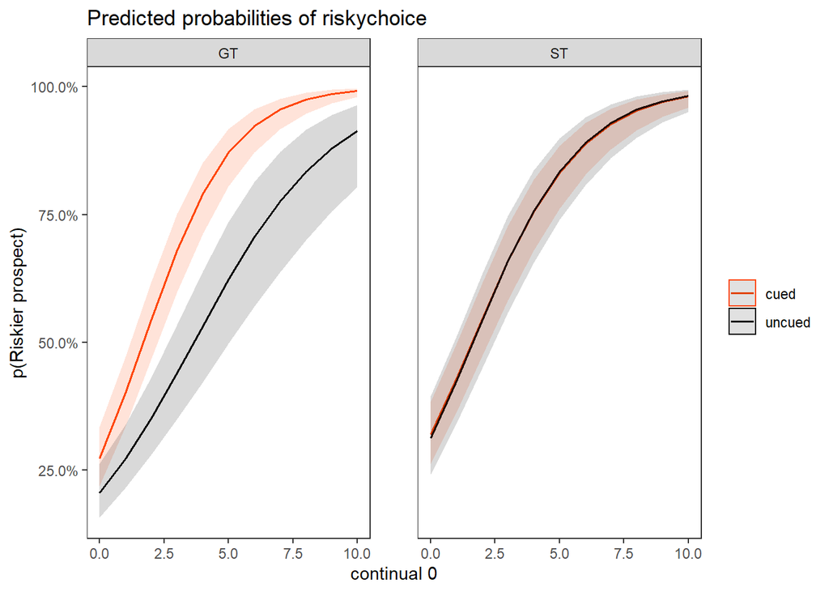